# Exploratory Analysis of Prosper Loans

Ye Peng Li

In fulfillment of Udacity Data Analyst Nanodegree Project 4

Prosper Loan data provided by Udacity

```
## 'data.frame':    113937 obs. of  81 variables:
##  $ ListingKey                         : Factor w/ 113048 levels "00003546482094282EF90E5",..: 7180 7192 6492 6514 6531 6534 6544 6551 6532 6532 ...
##  $ ListingNumber                      : int  193129 1209647 81716 658116 909464 1074836 750899 768193 1023355 1023355 ...
##  $ ListingCreationDate                : Factor w/ 34801 levels "00:00.0","00:00.1",..: 5431 16274 452 1489 22348 15402 30617 28572 25250 25250 ...
##  $ CreditGrade                        : Factor w/ 9 levels "","A","AA","B",..: 5 1 8 1 1 1 1 1 1 1 ...
##  $ Term                               : int  36 36 36 36 36 60 36 36 36 36 ...
##  $ LoanStatus                         : Factor w/ 12 levels "Cancelled","Chargedoff",..: 3 4 3 4 4 4 4 4 4 4 ...
##  $ ClosedDate                         : Factor w/ 2803 levels "","02:17.6","02:25.0",..: 2384 1 802 1 1 1 1 1 1 1 ...
##  $ BorrowerAPR                        : num  0.165 0.12 0.283 0.125 0.246 ...
##  $ BorrowerRate                       : num  0.158 0.092 0.275 0.0974 0.2085 ...
##  $ LenderYield                        : num  0.138 0.082 0.24 0.0874 0.1985 ...
##  $ EstimatedEffectiveYield            : num  NA 0.0796 NA 0.0849 0.1832 ...
##  $ EstimatedLoss                      : num  NA 0.0249 NA 0.0249 0.0925 ...
##  $ EstimatedReturn                    : num  NA 0.0547 NA 0.06 0.0907 ...
##  $ ProsperRating..numeric.            : int  NA 6 NA 6 3 5 2 4 7 7 ...
```

[output cut: 67 more lines]

# Univariate Plot Section

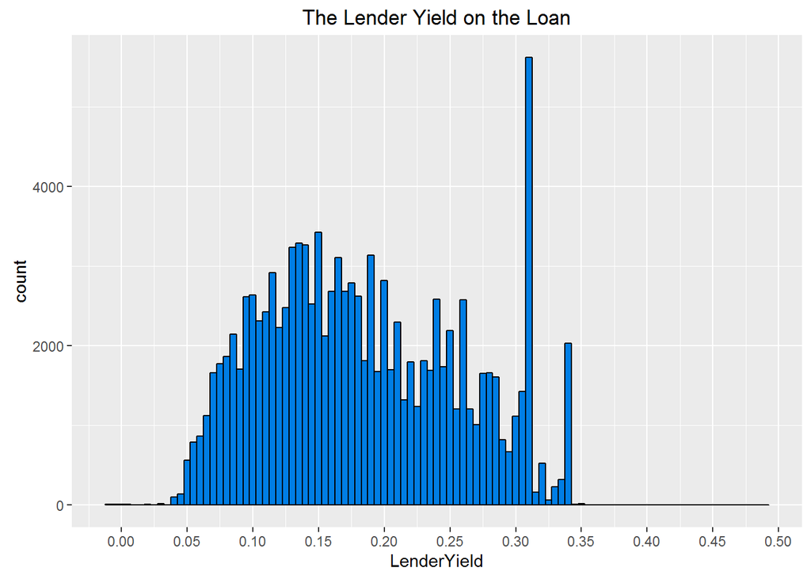

```
##    Min. 1st Qu.  Median    Mean 3rd Qu.    Max.
## -0.0100  0.1242  0.1730  0.1827  0.2400  0.4925
```

As an outsider from finance industry, it’s interesting to know the Lender yield. I’d suspect they have different lender yield for different term but here we get a median of 17.3%. However, there is a huge notable spike around 31%, which is a very attractive yield rate for the investors. This is something we can keep in mind while looking for further investigation.

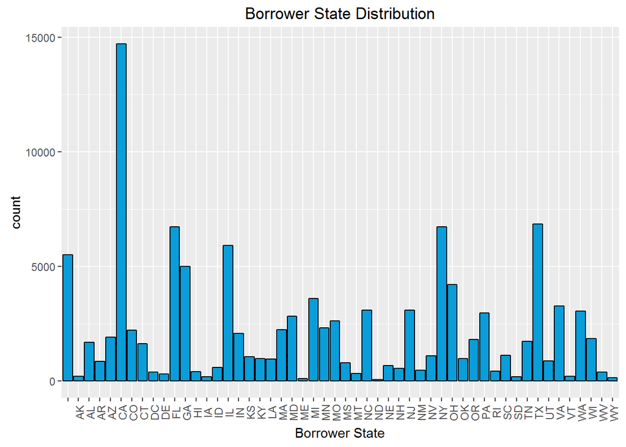

Califonia, Florida, New York and Texas have a huge amount of loan numbers than other states.These states are also famous for their population.

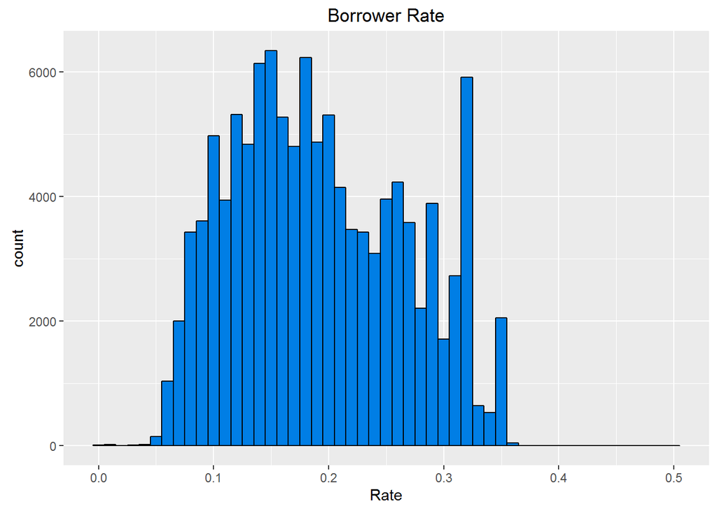

```
##    Min. 1st Qu.  Median    Mean 3rd Qu.    Max.
##  0.0000  0.1340  0.1840  0.1928  0.2500  0.4975
```

This chart is quite similar with the previous chat for Lender yield. As someone who’s completely new to the industry, I did not fully comprehend there’s a very linear and strong relationship between borrower rate and lender yield, which unfold later on during bivariate analysis.

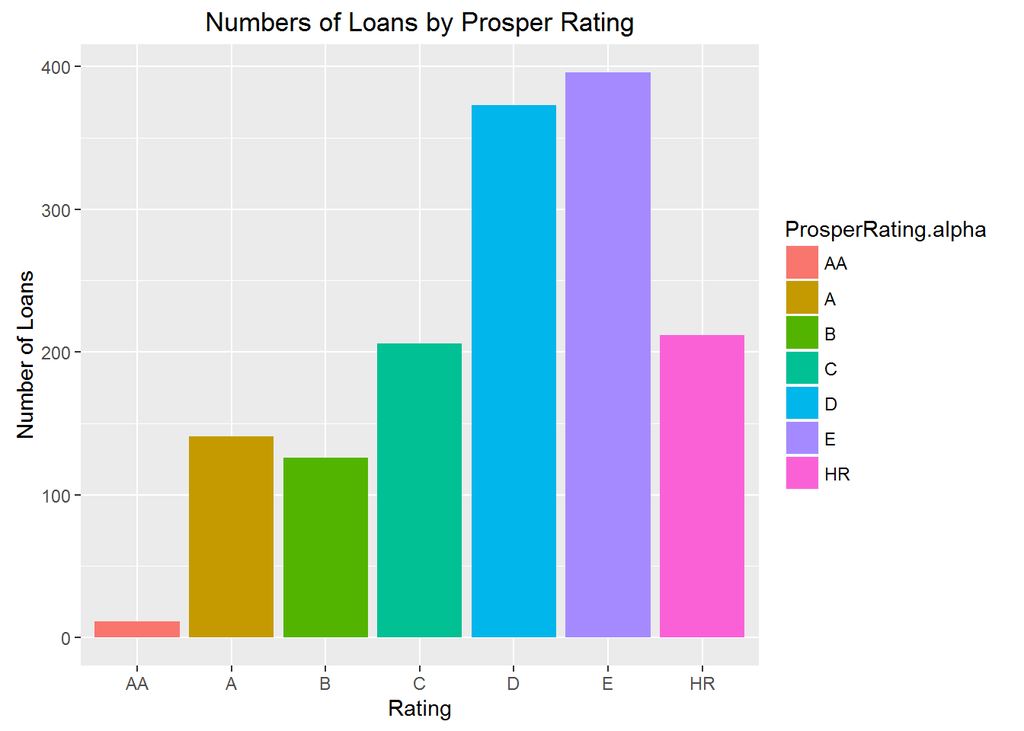

```
##    AA     A     B     C     D     E    HR    NA  NA's
##  5372 14551 15581 18345 14274  9795  6935     0 29084
```

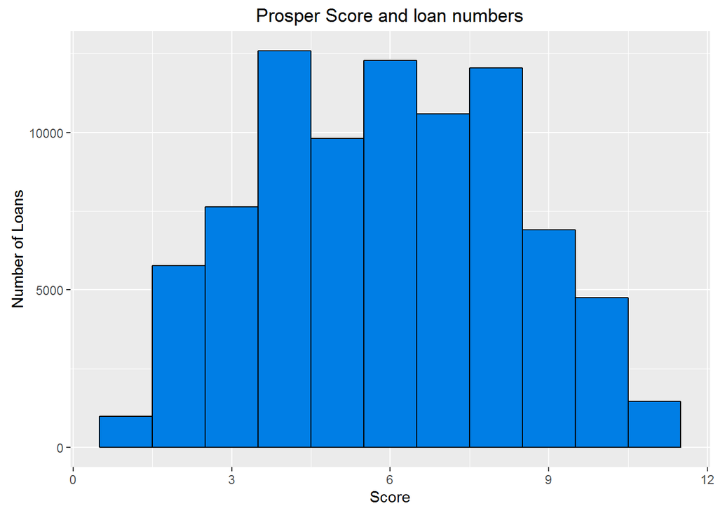

```
##    Min. 1st Qu.  Median    Mean 3rd Qu.    Max.    NA's
##    1.00    4.00    6.00    5.95    8.00   11.00   29084
```

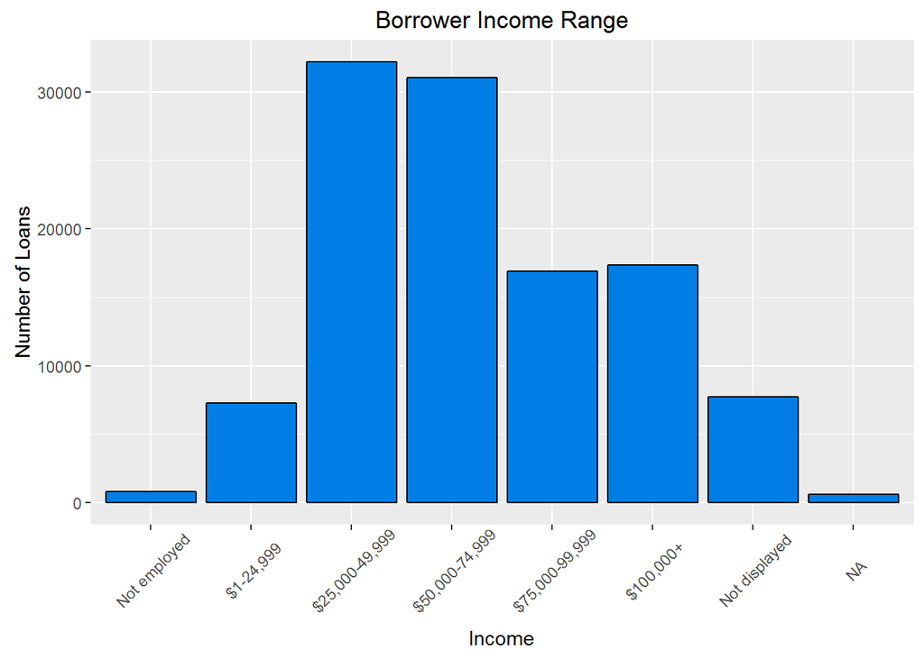

Surprisigly, people with less than 25,000 USD annual income were not the majority of borrowers. I suspect this trend indicate the customer segment Prosper Loan’s going after. It’s possible the main target are future home-owner, car-owner, studebt-debt payment.

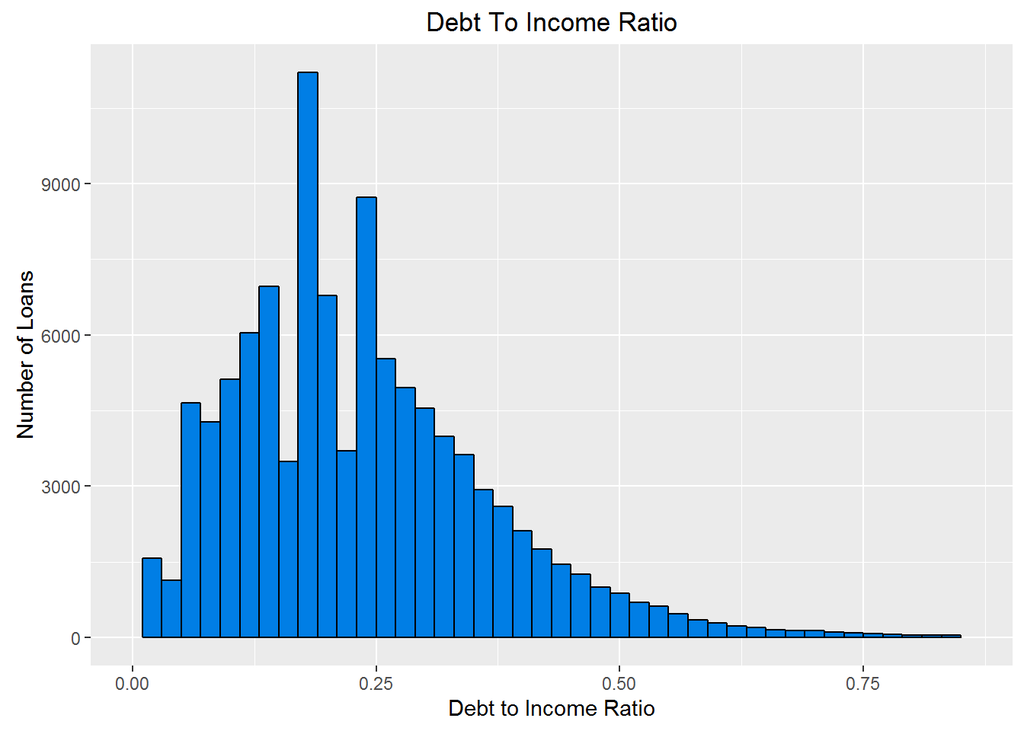

```
##    Min. 1st Qu.  Median    Mean 3rd Qu.    Max.    NA's
##   0.000   0.140   0.220   0.276   0.320  10.010    8554
```

The data has a long-tailed right-skewed but as expected. It’s expected the majority of people in U.S have a credit history, and the ratio should be low enough for a secured repayment. Seems like 25% is the threshold for most borrower.

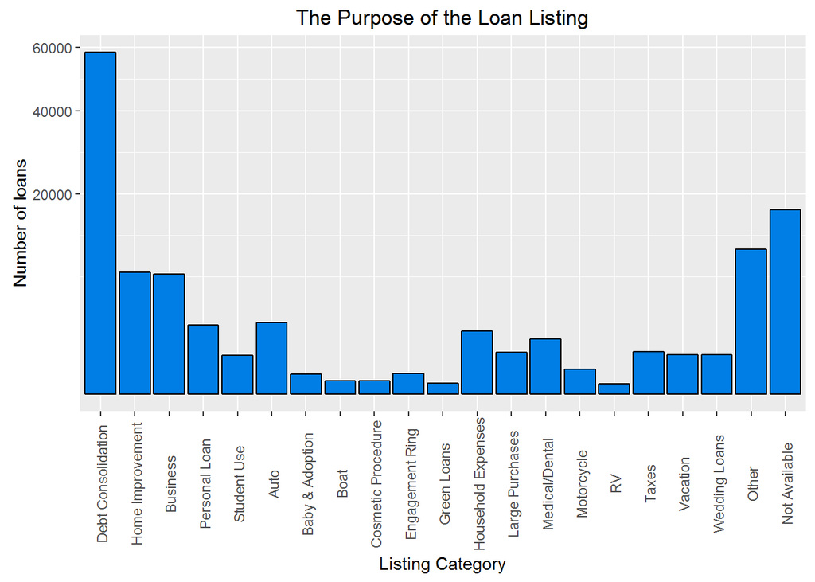

```
## Debt Consolidation   Home Improvement           Business
##              58308               7433               7189
##      Personal Loan        Student Use               Auto
##               2395                756               2572
##    Baby & Adoption               Boat Cosmetic Procedure
##                199                 85                 91
##    Engagement Ring        Green Loans Household Expenses
##                217                 59               1996
##    Large Purchases     Medical/Dental         Motorcycle
##                876               1522                304
##                 RV              Taxes           Vacation
##                 52                885                768
##      Wedding Loans              Other      Not Available
##                771              10494              16965
```

Again, we see not many people’re willing to explain the purpose of loan listing. There’s a surprisingly amount of needs for debt consolidation, more than 50%. Now the data for income range makes perfect sense, as young people are going out to the real world and start to repay their student debt, purchase cars, mortgage their apartment, etc. Therefore, people already been in the workforce for many decades wouldn’t need much Prosper service.

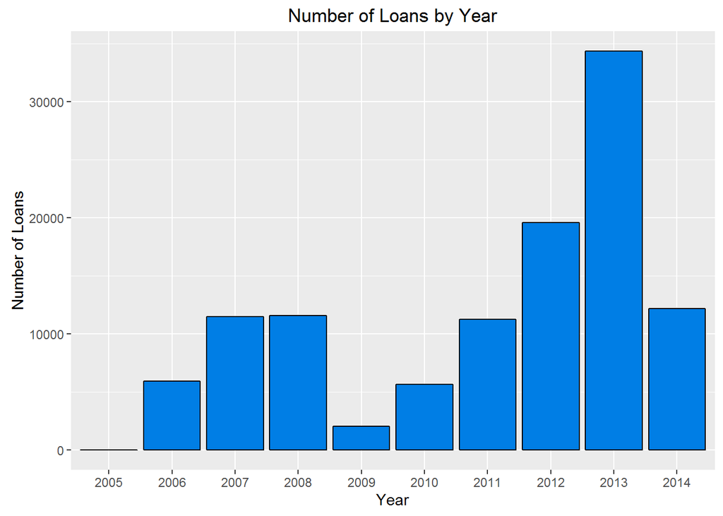

```
##  2005  2006  2007  2008  2009  2010  2011  2012  2013  2014
##    22  5906 11460 11552  2047  5652 11228 19553 34345 12172
```

Prosper loan dataset start to have records from quarter 4 in 2005 and last updated by Udacity on 3/14/2014. It might be the reason that 2005 and 2014 look considerately lower than the rest.

The chart took a plunge in 2009 and exploded the year after and peaked in 2013. Now, this period is coincide with the 2008 Global Financial Crisis and government must have conducted certain action toward credit-typed business. Doing a quick Google search, we now understand the period of October 15, 2008 to July 13, 2009 is Prosper’s QuietSEC Period, from which they are suspended for lending activities upon SEC approval. Prosper relaunched in July 2009, most notable hypothesis is Prosper needed to adjust their scoring algorigthm to ensure tighter interest rate & stricter rating criteria.

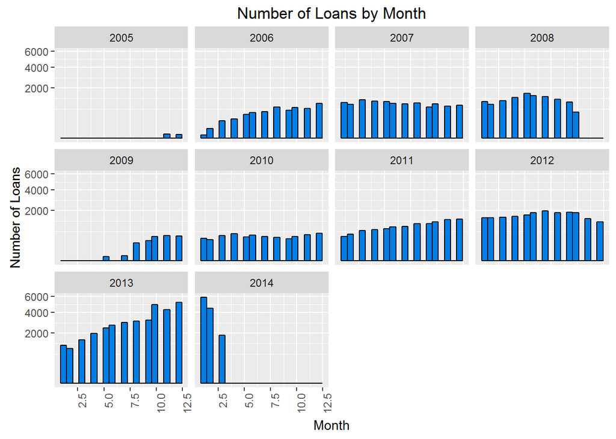

Again, we so almost little to no loan activities in 2009 and the extremely high growth in 2013. Probably in 2013, business went back to normal and the demand for credit increased.

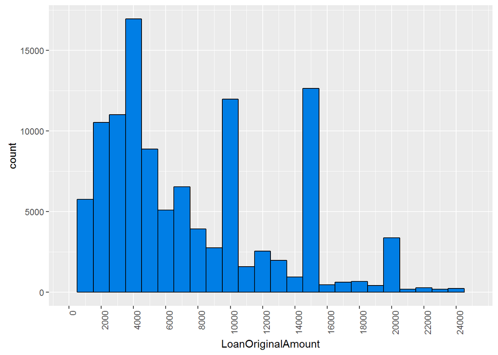

```
##    Min. 1st Qu.  Median    Mean 3rd Qu.    Max.
##    1000    4000    6500    8337   12000   35000
```

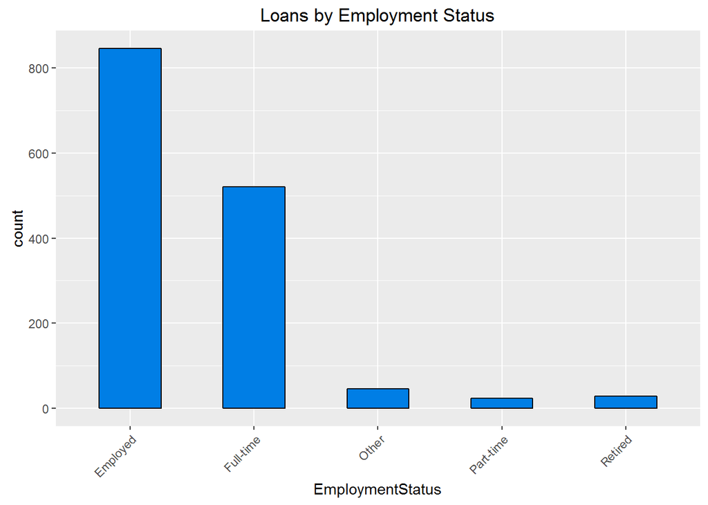

```
##                    Employed     Full-time Not available  Not employed
##          2255         67322         26355          5347           835
##         Other     Part-time       Retired Self-employed
##          3806          1088           795          6134
```

Among these criteria, probably people would tick in “Employed” box & would not fill-in other details, which also explained why self-employed borrowers are higher than part-time employment.

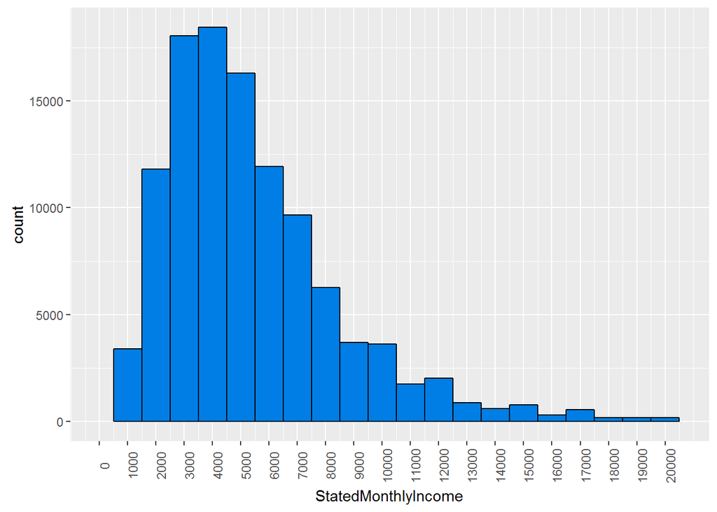

```
##    Min. 1st Qu.  Median    Mean 3rd Qu.    Max.
##       0    3200    4667    5608    6825 1750000
```

Median income range is at $4667 and mean of $5608 which is quite average for a professional with few years of experience.

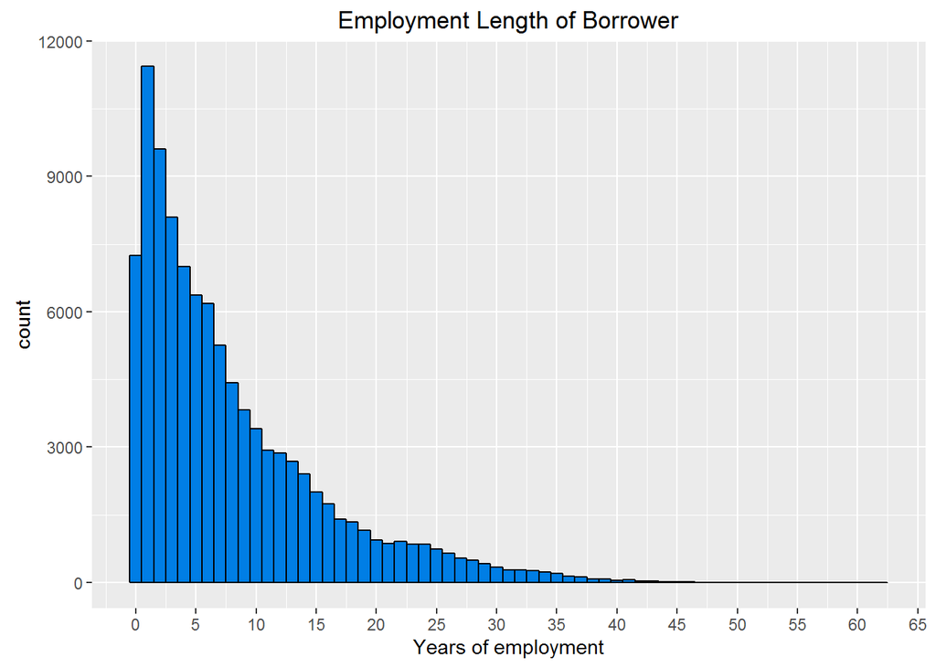

```
##    Min. 1st Qu.  Median    Mean 3rd Qu.    Max.    NA's
##   0.000   2.167   5.583   8.006  11.420  62.920    7625
```

As expected, the data is in favor of people have fewer years of employment and as they aging, they do not need much loan as before.

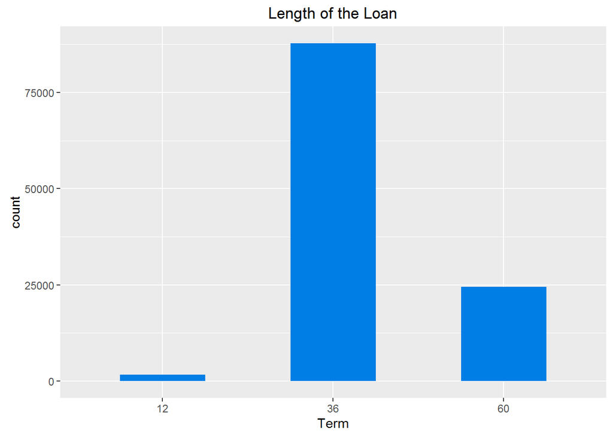

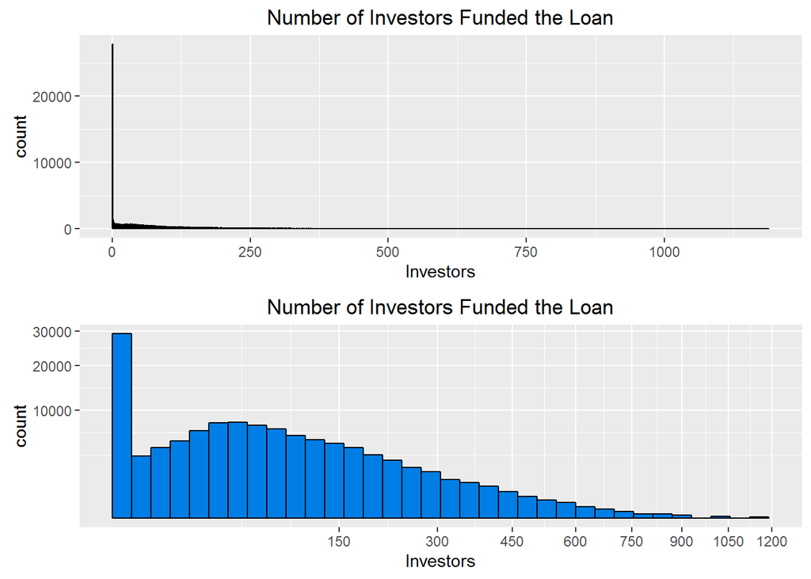

```
##
## FALSE  TRUE
## 86123 27814
```

Axis transformation for the long tailed data makes the trends more clear. Table shows that out of 113937 loans, about 24.4% are funded individually. This is a very high concentration toward 1 investor. However, if we keep in mind 75% of loan are below $12000. This would make sense.

# Univariate Analysis

### What is/are the main feature(s) of interest in your dataset?

For the sake of this analysis, let’s split the dataset into 2 different players:

For Borrower, I believe the Prosper Score, Proser Rating (both numeric & alphabet) are the main indicators of a quality of borrowers. Further bivariate analysis would help to learn about these 2.

For Lender, I now understand Lender Yield is the most important factor for investor.

As a marketplace, Prosper would be more interest in Service Fees & Collection Fees but we would not dive into these variables in our analysis.

### What other features in the dataset do you think will help support your investigation into your feature(s) of interest?

Also, I didn’t find nothing so interesting about risk score and income level, two variable that I was expecting more. On the other hand, maybe this variables have more to tell when related to others. I would like to understand better why loans with term of 36-months are more dispersed than 60 months. Also I want to find out why risky loans are classified that way.

### Did you create any new variables from existing variables in the dataset?

Of the features you investigated, were there any unusual distributions? Did you perform any operations on the data to tidy, adjust, or change the form of the data? If so, why did you do this?

Yes, there is few unsual distribution, I was particularly pay attention to the high spike in lender yield & borrower rate and the spike in LoanOriginalAmount that people tend to buy in bulk. I was factorizing data and since categorical variables enter into statistical models differently than continuous variables, storing data as factors insures that the modeling functions will treat such data correctly. Another unsual thing is that similarity of the distribution for lender yield and borrower rate. I will investigate this problem in the bivariate plot section.

# Bivariate Plot Section

### Part One

Part one is to investigate how lenders try to get their profit max and Prosper Rating is an important fator for lender’s choice.

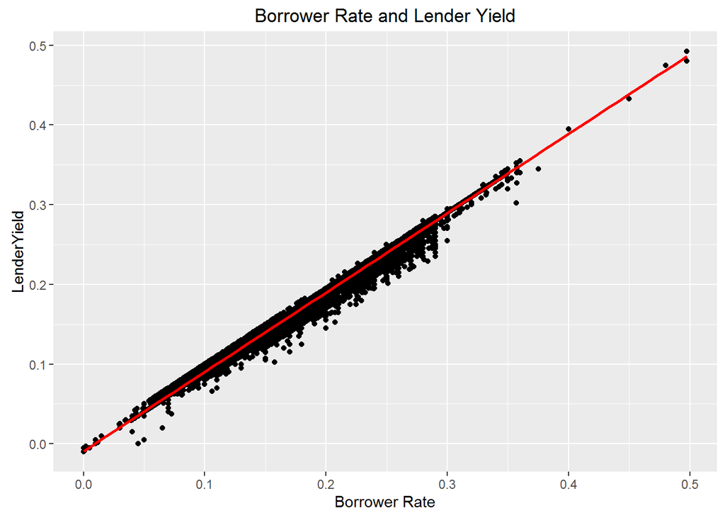

[output not shown]

The sample estimated corrolation coeffient of Lender Yield and Borrower Rate is nearly 1. Such a strong corrolation may mean they are measuring same thing just with different terms. But from the concept lender yield and borrower rate are totally different. So they should be have a strong linear realationship.Then what’s the factor associated with borrower rate?

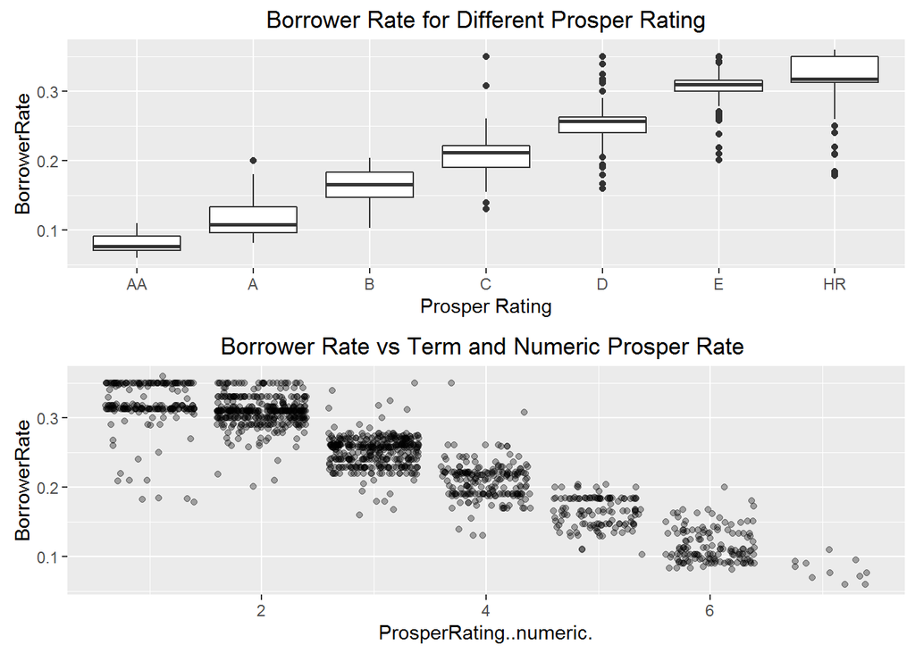

As the Proser rating gets worse the borrower rate is increasing. It does make sense. But should the lender choose more bad prosper rating customer so that they can make more profit?

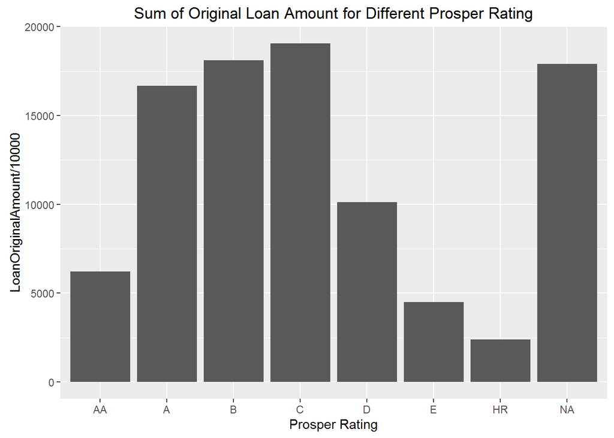

Not necessarily! Lender profit amount depends not only on borrower rate but also on the original loan amount. This graph shows Prosper rateing in “A”,“B”,“c”,“D” groups have larger amount of original loan than other groups. Why do lenders prefer low to middle lever borrow rate instead of higher borrower rate?

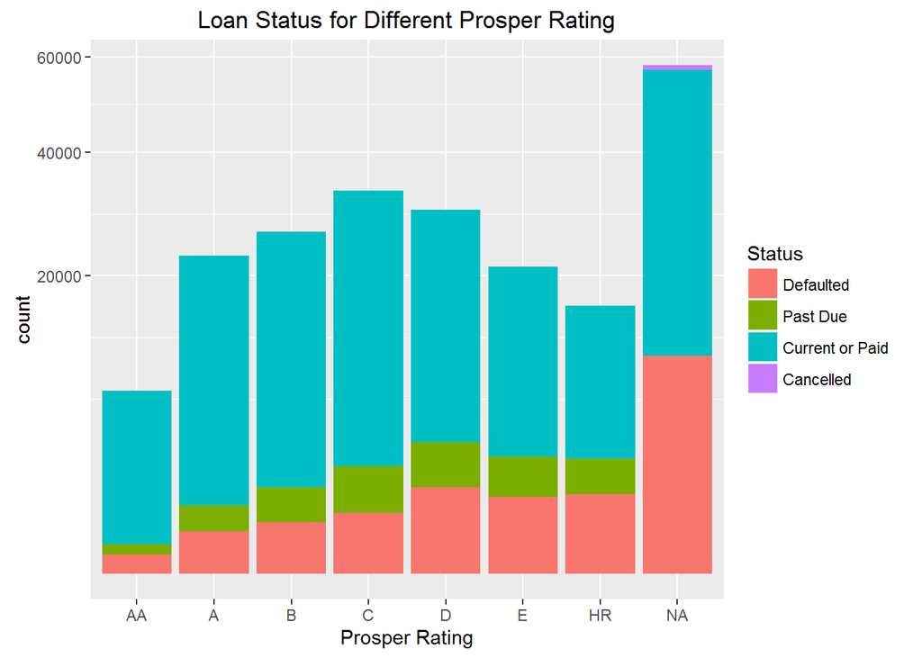

Loan status study shows majority of the loans in each Prosper rating are Current or paid. And I also noticed that percentage of past due loans increasing while Proper rating gets worse. It means though bad prosper rating has higer borrower rate it also has more risk for delay of the loan payment.

```
##                    Status
## ProsperRating.alpha Defaulted Past Due Current or Paid Cancelled
##                  AA        83       25            5264         0
##                  A        405      154           13992         0
##                  B        588      278           14715         0
##                  C        840      489           17016         0
##                  D       1677      457           12140         0
##                  E       1324      375            8096         0
##                  HR      1424      289            5222         0
##                  NA         0        0               0         0
```

How to estimate the actual lender’s profit amount? I used a simple way to calculate the first year’s lender profit. It is lender profit times original loan amount. This is only fit for the first year profit with fixed APR.

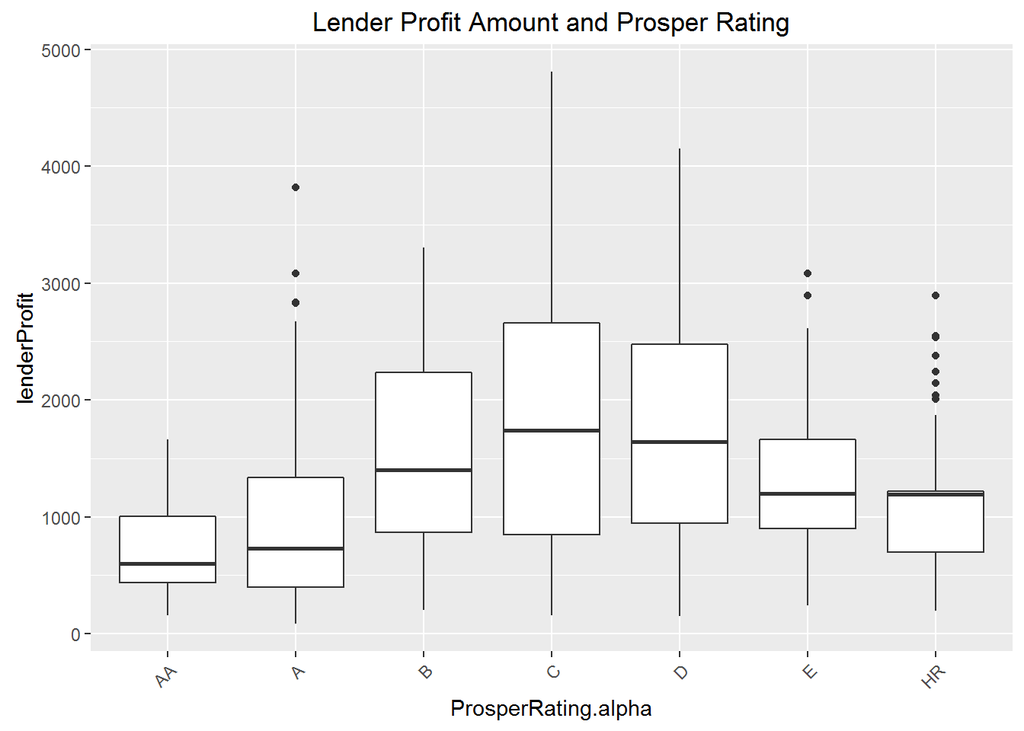

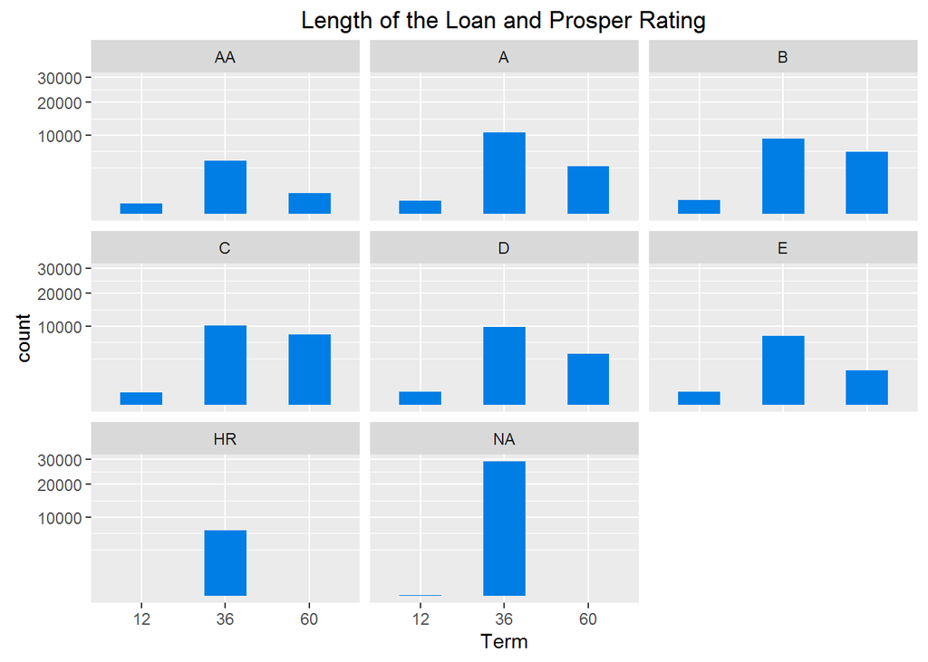

Because of the risk of delay of payment in the long run for bad Prosper rating the lenders may choose relatively short term for those borrowers. This graph shows the amount of 60 month term decrease for rate C to HR.

```
##                    Term
## ProsperRating.alpha    12    36    60
##                  AA   181  4491   700
##                  A    269 10664  3618
##                  B    316  9005  6260
##                  C    264 10181  7900
##                  D    295  9806  4173
##                  E    288  7613  1894
##                  HR     0  6935     0
##                  NA     0     0     0
```

Table result comfirmed the graph’s consumption. Lenders seems gives shorter term for the bad rate borrowers than the good rate borrowers.

### Part Two

Part Two is to investigate the factors inflence Prosper Rating

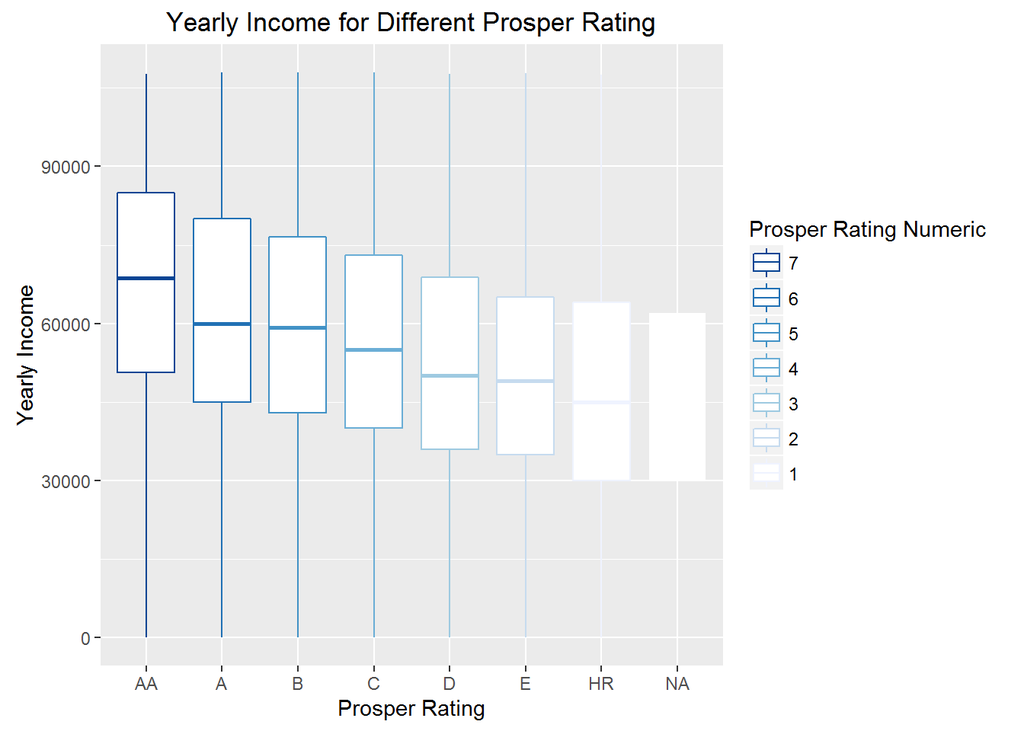

```
##     Min.  1st Qu.   Median     Mean  3rd Qu.     Max.
##        0    38400    56000    67300    81900 21000000
```

For this graph, we explicitly excluded MonthlyIncome more than 9000 and no income as there’re few outliers have monthly income more than 9000 and the chart cannot displayed properly.

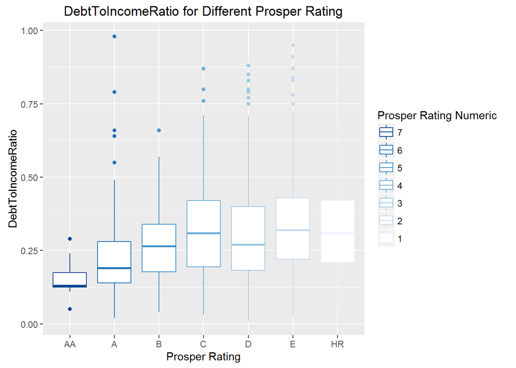

```
##    Min. 1st Qu.  Median    Mean 3rd Qu.    Max.    NA's
##   0.000   0.140   0.220   0.276   0.320  10.010    8554
```

As expected higer Debt ratio borrowers stay in worse Prosper rating group.

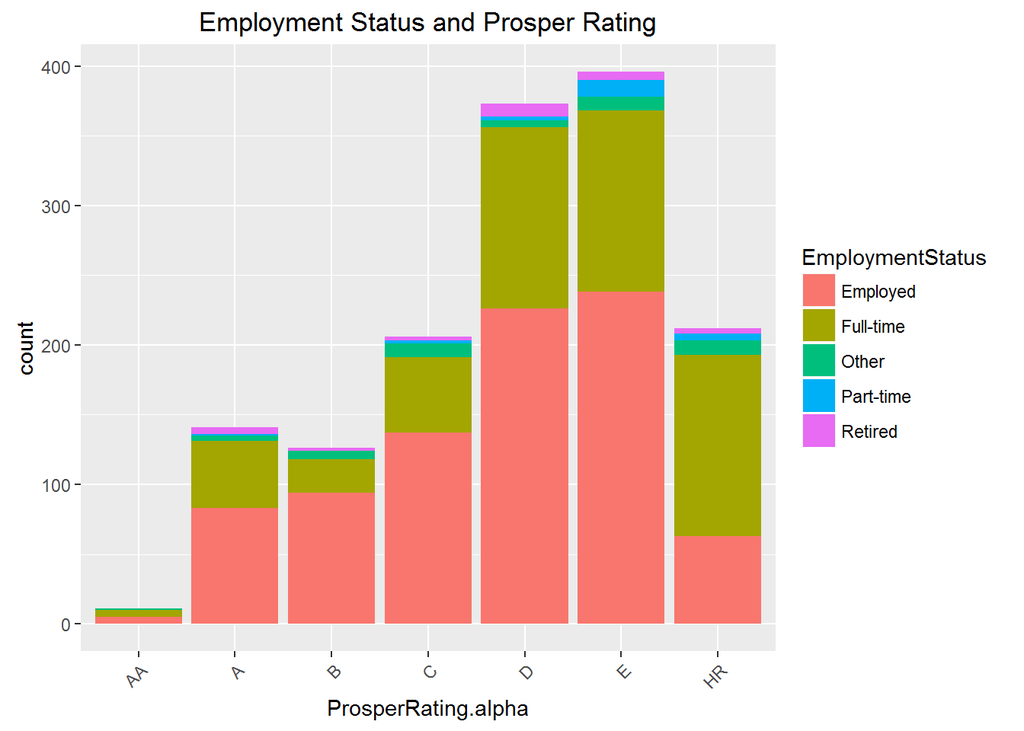

This graphy shows higher percentage of part-time workers fall in to Prosper rating C to HR group.

### Part Three

Other interesting investigations

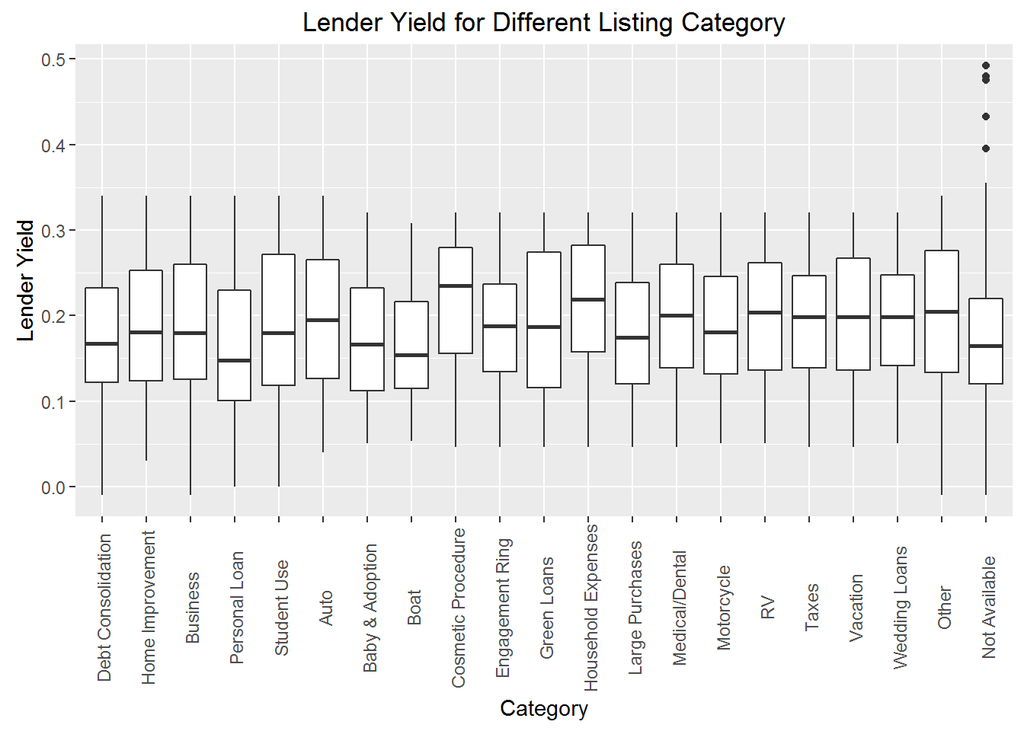

I initially thought there must be better yield for riskier category but it seems like there’s no relationship here.

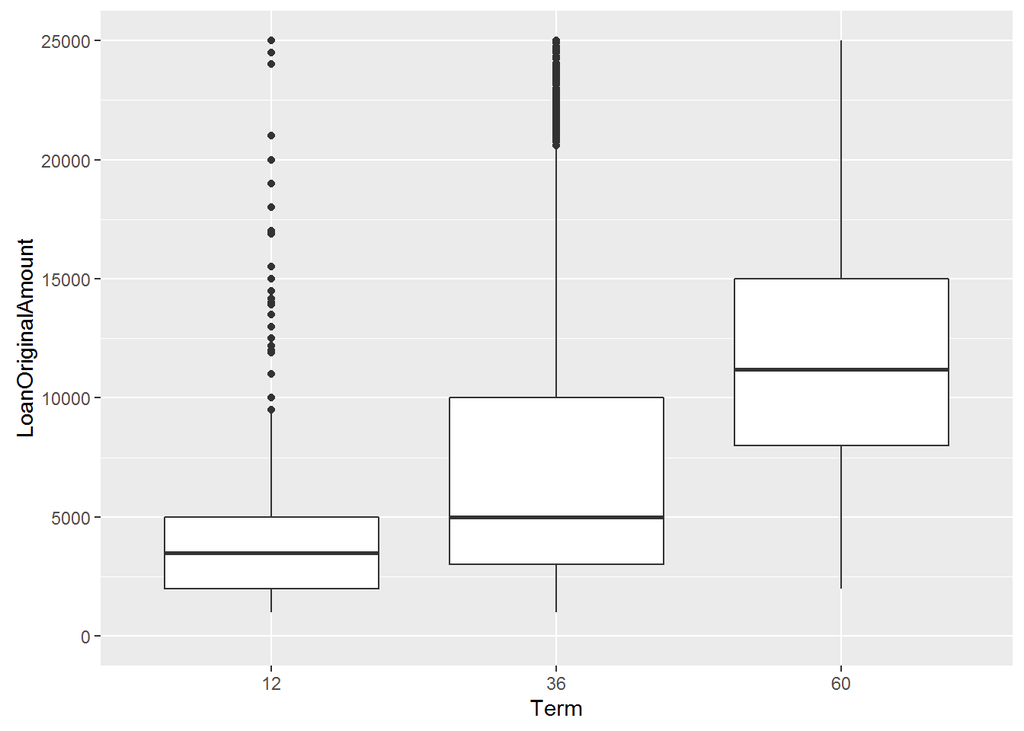

This chart is a new interesting insight, although the majority of loan are in 36-month term. The Loan original amount is significantly higher for 60 months term. Let’s see if it’s hold true for Lender Yield.

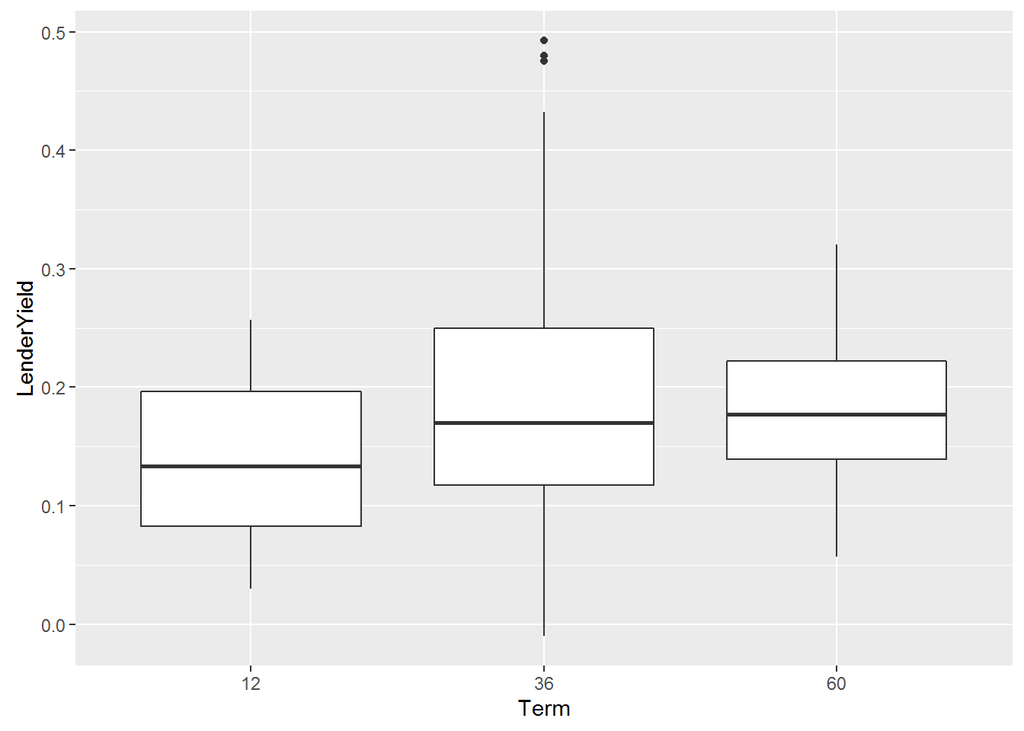

Unfortunately, this is not the case. Term Loan have higher Loan Original Amount because it’d need more time to repay those loans.

# Bivariate Analysis

### Talk about some of the relationships you observed in this part of the investigation. How did the feature(s) of interest vary with other features in the dataset?

I want to explore 2 main variables Lender Yield and Prosper Rating. First I found there is strong linear correlation between Lender Yield and Borrower Rate. Then from the investigation of Borrower Rate and Proper Rating I found Prosper Rating is a strong infuencor on Borrowers Rate. It makes me interested in if lenders will choose bad Prosper Rating customers to make more profit. After exploring the distribution of Original Loan Amount vs Prosper Rating and the distribution of Loan Status vs Proper Rating, I found lenders prefer intermediate rating Borrowers for the past due of loan is fewer. And simple caculation of first year’s profit amount shows the intermediate part borrowers return more profit to lenders than other groups. So far, the only relationship I found is above. Other factor I was trying to compare was not having any particular relationship.

### Did you observe any interesting relationships between the other features (not the main feature(s) of interest)?

No

### What was the strongest relationship you found?

The relationship between (Prosper Rating and Lender Yield) and (Prosper Rating and Borrower Rate) has an inversed relationship. The higher the rating, the lower the borrower rate and lender yield.

# Multivariate Plots Section

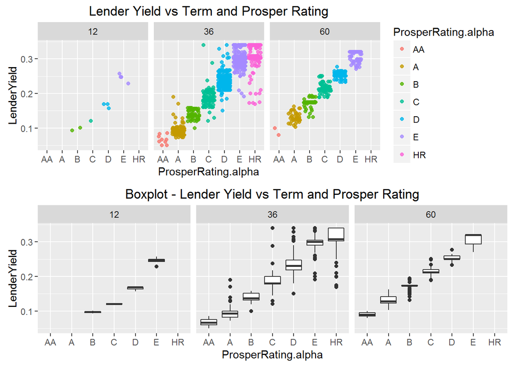

This is a closer look for lender yield vs prosper rating. The majority of loans opt-in for 36-month term and the return for 36-month and 60-month are just higher than 12-month, also considering the fact there’re less loan in 12-month term than other term.

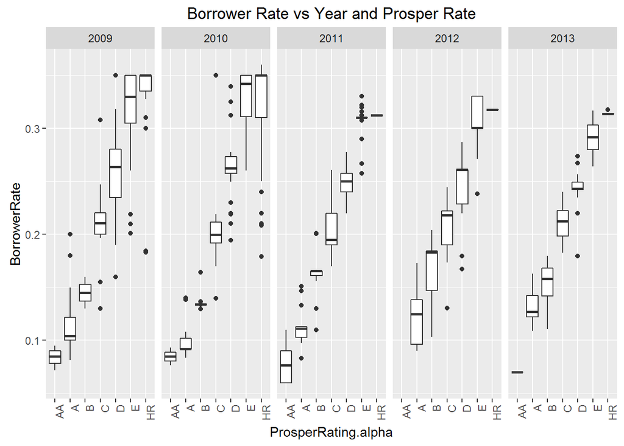

Another thing interesting is that the time the Borrower Rate is depending on the Prosper Rate began from 2009, not 2005. Let see what’s following table says.

```
##                    LoanOriginationDate_year
## ProsperRating.alpha 2005 2006 2007 2008 2009 2010 2011 2012 2013 2014
##                  AA    0    0    0    0  297  639  551 1076 1721 1088
##                  A     0    0    0    0  458  963 1479 2760 5943 2948
##                  B     0    0    0    0   98  536 1610 3071 7558 2708
##                  C     0    0    0    0  390  594  888 3891 9223 3359
##                  D     0    0    0    0  333 1311 3273 3222 5017 1118
##                  E     0    0    0    0  193  630 2306 1904 3914  848
##                  HR    0    0    0    0  207  906 1121 3629  969  103
##                  NA    0    0    0    0    0    0    0    0    0    0
```

The table shows ever since 2009 the lendes have realized the importance of Prosper Rating. From then they set up the Prosper rating and gave borrowers different rate according to this rate.

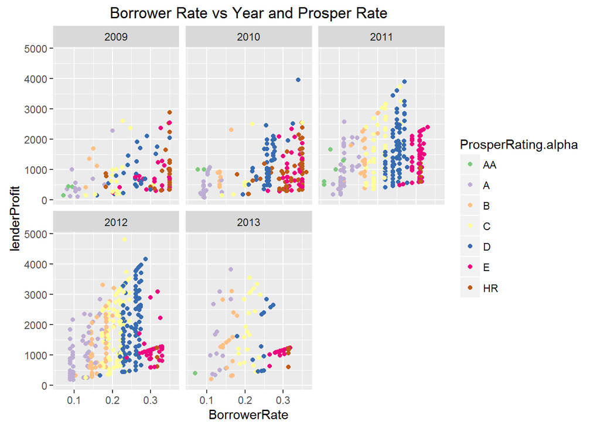